# Seventh Week: Generalized Linear Models

Murder or suicide

Amirabbs Jalali 93105556

2018-04-27 21:18:13

> با توجه به سوالات مرگ و میر در آمریکا به سوالات زیر پاسخ دهید.

در سوالات این تمرین به داده ها و کتابخانه های زیر نیاز داریم.

```r
library(dplyr)
library(ggplot2)
library(highcharter)
library(readr)
library(psych)
library(corrplot)
library(car)
library(mgcv)
library(caret)
library(e1071)
library(pROC)
library(ROCR)
library(h2o)
library(data.table)
library(scales)
library(grid)
library(gridExtra)
library(tidyr)

murder_suicide = read.csv("../../Data/murder_suicide/murder_suicide.csv")
```

۱. از میان متغیرهای داده مرگ و میر یک زیرمجموعه ایی بدون حشو در نظر بگیرید. ماتریس همبستگی متغیرهای مختلف را به دست آورده و سپس رسم نمایید. علاوه بر این نمودار پراکنش متغیرهای انتخاب شده را همزمان نسبت به هم رسم نمایید.

جواب:  
برای نمایش بهتر از پارامترهای انتخابی برترین ها از نظر همبستگی انتخاب شده اند. میزان تحصیلات در یک ستون ادقام شده و به صورت دستی مقادیر یک سطح شده اند. برای مقادیر غیرعددی نیز مقادیر عددی در نظرگرفته شده است.

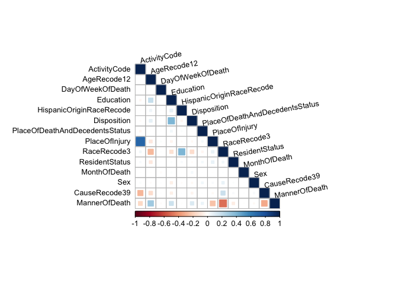

```r
murder_suicide %>%
  mutate(Education = ifelse(EducationReportingFlag, Education2003Revision ,ifelse(-1<Education1989Revision && Education1989Revision<9,1,ifelse(8<Education1989Revision && Education1989Revision<12, 2, ifelse(Education1989Revision == 12, 3, ifelse(12<Education1989Revision && Education1989Revision<16,4,ifelse(Education1989Revision == 99, 9, 5))))))) %>% # transform 1080 to standard 2003 Education degrees
  mutate(Disposition = ifelse(MethodOfDisposition == 'U', 0 , ifelse(MethodOfDisposition == 'O', 1 , ifelse(MethodOfDisposition == 'B', 2 , 3)))) %>% # transform disposition to numeric
  mutate(InjuryAtWork = ifelse(InjuryAtWork == 'Y', 1, ifelse(InjuryAtWork == 'N', 0, -1))) %>%
  mutate(Sex = ifelse(Sex == 'M', 1, 0) ) %>%
  mutate(MannerOfDeath = ifelse(MannerOfDeath == 2, 1, 0)) %>%
  select(ActivityCode, AgeRecode12, DayOfWeekOfDeath, Education, HispanicOriginRaceRecode, Disposition, PlaceOfDeathAndDecedentsStatus, PlaceOfInjury, RaceRecode3, ResidentStatus, MonthOfDeath, Sex, CauseRecode39 ,MannerOfDeath) -> selected_ms # selected param.

# plot selected param.
cor_ms = cor(selected_ms)
corrplot(cor_ms, method = "square", type = "lower", tl.col = "black", tl.srt = 10, tl.cex = 0.8)
```

```r
# find top 10 cor.
knitr::kable(abs(sort(-abs(cor_ms['MannerOfDeath',]))[2:11]))
```

|  | x |
| --- | --- |
| RaceRecode3 | 0.4968254 |
| CauseRecode39 | 0.3281544 |
| AgeRecode12 | 0.3000836 |
| PlaceOfInjury | 0.2431710 |
| Education | 0.1737872 |
| ActivityCode | 0.1650709 |
| Disposition | 0.1249095 |
| ResidentStatus | 0.0737889 |
| PlaceOfDeathAndDecedentsStatus | 0.0615197 |
| Sex | 0.0200664 |

```r
top_10_cor = selected_ms %>%
  select(RaceRecode3,CauseRecode39,AgeRecode12,PlaceOfInjury,Education,ActivityCode,Disposition,ResidentStatus,PlaceOfDeathAndDecedentsStatus,Sex)
```

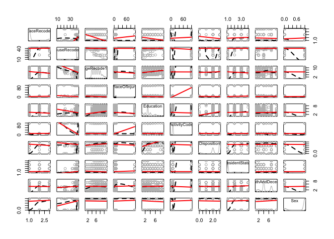

```r
dist_samp = sample_frac(top_10_cor, 0.1)
# distribution matrix plot for 10% sample of top 10 cor.
scatterplotMatrix(dist_samp, regLine = list(method=lm, lty=1, col="red") ,smooth=list(smoother=loessLine, spread=FALSE, lty.smooth=2, col.smooth="black"), col = "gray")
```

۲. اثر هر یک از متغیرهای جنسیت، نژاد،آموزش، سن و نحوه تدفین را بر مرگ یا خودکشی ارزیابی کنید.

```r
# Sex
s = cor.test(selected_ms$Sex, selected_ms$MannerOfDeath, method = 'spearman')
print(s)
```

```
    Spearman's rank correlation rho

data:  selected_ms$Sex and selected_ms$MannerOfDeath
S = 3.6684e+13, p-value = 8.888e-07
alternative hypothesis: true rho is not equal to 0
sample estimates:
       rho
-0.0200664
```

```r
# Race
r = cor.test(selected_ms$RaceRecode3, selected_ms$MannerOfDeath, method = 'spearman')
print(r)
```

```
    Spearman's rank correlation rho

data:  selected_ms$RaceRecode3 and selected_ms$MannerOfDeath
S = 5.322e+13, p-value < 2.2e-16
alternative hypothesis: true rho is not equal to 0
sample estimates:
       rho
-0.4798949
```

```r
# Education
e = cor.test(selected_ms$Education, selected_ms$MannerOfDeath, method = 'spearman')
print(e)
```

```
    Spearman's rank correlation rho

data:  selected_ms$Education and selected_ms$MannerOfDeath
S = 2.9013e+13, p-value < 2.2e-16
alternative hypothesis: true rho is not equal to 0
sample estimates:
      rho
0.1932501
```

```r
# Age
a = cor.test(selected_ms$AgeRecode12, selected_ms$MannerOfDeath, method = 'spearman')
print(a)
```

```
    Spearman's rank correlation rho

data:  selected_ms$AgeRecode12 and selected_ms$MannerOfDeath
S = 2.5161e+13, p-value < 2.2e-16
alternative hypothesis: true rho is not equal to 0
sample estimates:
      rho
0.3003515
```

```r
# Disposition
d = cor.test(selected_ms$Disposition, selected_ms$MannerOfDeath, method = 'spearman')
print(d)
```

```
    Spearman's rank correlation rho

data:  selected_ms$Disposition and selected_ms$MannerOfDeath
S = 2.8539e+13, p-value < 2.2e-16
alternative hypothesis: true rho is not equal to 0
sample estimates:
     rho
0.206419
```

۳. با استفاده از مدل رگرسیون لاجستیک یک مدل به داده ها برازش دهید و سپس آن را نقص یابی کنید.

```r
rml = glm(MannerOfDeath~., family = binomial(link = 'logit'), data = selected_ms)
summary(rml)
```

```
Call:
glm(formula = MannerOfDeath ~ ., family = binomial(link = "logit"),
    data = selected_ms)

Deviance Residuals:
    Min       1Q   Median       3Q      Max
-8.4904  -0.2538   0.2532   0.3242   8.4904

Coefficients:
                                 Estimate Std. Error  z value Pr(>|z|)
(Intercept)                    159.943477   1.324729  120.737  < 2e-16 ***
ActivityCode                    -0.168298   0.003295  -51.077  < 2e-16 ***
AgeRecode12                      0.107508   0.009001   11.944  < 2e-16 ***
DayOfWeekOfDeath                -0.008421   0.007819   -1.077  0.28153
Education                        0.069465   0.010077    6.893 5.45e-12 ***
HispanicOriginRaceRecode         0.175293   0.010245   17.109  < 2e-16 ***
Disposition                      0.044810   0.018990    2.360  0.01829 *
PlaceOfDeathAndDecedentsStatus   0.084538   0.007550   11.197  < 2e-16 ***
PlaceOfInjury                   -0.109439   0.001506  -72.681  < 2e-16 ***
RaceRecode3                     -0.906751   0.022263  -40.729  < 2e-16 ***
ResidentStatus                  -0.077298   0.027042   -2.858  0.00426 **
MonthOfDeath                    -0.000258   0.004642   -0.056  0.95568
Sex                              0.258755   0.036655    7.059 1.68e-12 ***
CauseRecode39                   -3.917455   0.032294 -121.305  < 2e-16 ***
---
Signif. codes:  0 '***' 0.001 '**' 0.01 '*' 0.05 '.' 0.1 ' ' 1

(Dispersion parameter for binomial family taken to be 1)

    Null deviance: 71216  on 59978  degrees of freedom
Residual deviance: 24231  on 59965  degrees of freedom
AIC: 24259

Number of Fisher Scoring iterations: 25
```

جواب:  
در این مدل بیشینه خطا در حدود ۸ درآمده و میانگین آن ها نزدیک به صفر است که نتیجه ی خوبی است. روز و ماه خودکشی نیز ربط تاثیرگذاری در مدل ما ندارد و قابل پیش بینی بود. اختلاف Null و Residual زیاد است و این نشانه ای بر بهتر بودن مدل ما از مدل بدون پیش بینی است. به طور کلی مدل به خوبی برازش یافته.

۴. با استفاده از سه نمودار خروجی مدل را نسبت به داده واقعی ارزیابی کنید.

جواب:  
توابع زیر برای رسم نمودارها استفاده شده است.

```r
AccuracyCutoffInfo <- function( train, test, predict, actual )
{
    # change the cutoff value's range as you please
    cutoff <- seq( .3, .9, by = .01 )

    accuracy <- lapply( cutoff, function(c)
    {
        # use the confusionMatrix from the caret package
        cm_train <- confusionMatrix( as.numeric( train[[predict]] > c ), train[[actual]] )
        cm_test  <- confusionMatrix( as.numeric( test[[predict]]  > c ), test[[actual]]  )

        dt <- data.table( cutoff = c,
                          train  = cm_train$overall[["Accuracy"]],
                          test   = cm_test$overall[["Accuracy"]] )
        return(dt)
    }) %>% rbindlist()

    # visualize the accuracy of the train and test set for different cutoff value
    # accuracy in percentage.
    accuracy_long <- gather( accuracy, "data", "accuracy", -1 )

    plot <- ggplot( accuracy_long, aes( cutoff, accuracy, group = data, color = data ) ) +
            geom_line( size = 1 ) + geom_point( size = 3 ) +
            scale_y_continuous( label = percent ) +
            ggtitle( "Train/Test Accuracy for Different Cutoff" )

    return( list( data = accuracy, plot = plot ) )
}

ConfusionMatrixInfo <- function( data, predict, actual, cutoff )
{
    # extract the column ;
    # relevel making 1 appears on the more commonly seen position in
    # a two by two confusion matrix
    predict <- data[[predict]]
    actual  <- relevel( as.factor( data[[actual]] ), "1" )

    result <- data.table( actual = actual, predict = predict )

    # caculating each pred falls into which category for the confusion matrix
    result[ , type := ifelse( predict >= cutoff & actual == 1, "TP",
                      ifelse( predict >= cutoff & actual == 0, "FP",
                      ifelse( predict <  cutoff & actual == 1, "FN", "TN" ) ) ) %>% as.factor() ]

    # jittering : can spread the points along the x axis
    plot <- ggplot( result, aes( actual, predict, color = type ) ) +
            geom_violin( fill = "white", color = NA ) +
            geom_jitter( shape = 1 ) +
            geom_hline( yintercept = cutoff, color = "blue", alpha = 0.6 ) +
            scale_y_continuous( limits = c( 0, 1 ) ) +
            scale_color_discrete( breaks = c( "TP", "FN", "FP", "TN" ) ) + # ordering of the legend
            guides( col = guide_legend( nrow = 2 ) ) + # adjust the legend to have two rows
            ggtitle( sprintf( "Confusion Matrix with Cutoff at %.2f", cutoff ) )

    return( list( data = result, plot = plot ) )
}

ROCInfo <- function( data, predict, actual, cost.fp, cost.fn )
{
    # calculate the values using the ROCR library
    # true positive, false postive
    pred <- prediction( data[[predict]], data[[actual]] )
    perf <- performance( pred, "tpr", "fpr" )
    roc_dt <- data.frame( fpr = perf@x.values[[1]], tpr = perf@y.values[[1]] )

    # cost with the specified false positive and false negative cost
    # false postive rate * number of negative instances * false positive cost +
    # false negative rate * number of positive instances * false negative cost
    cost <- perf@x.values[[1]] * cost.fp * sum( data[[actual]] == 0 ) +
            ( 1 - perf@y.values[[1]] ) * cost.fn * sum( data[[actual]] == 1 )

    cost_dt <- data.frame( cutoff = pred@cutoffs[[1]], cost = cost )

    # optimal cutoff value, and the corresponding true positive and false positive rate
    best_index  <- which.min(cost)
    best_cost   <- cost_dt[ best_index, "cost" ]
    best_tpr    <- roc_dt[ best_index, "tpr" ]
    best_fpr    <- roc_dt[ best_index, "fpr" ]
    best_cutoff <- pred@cutoffs[[1]][ best_index ]

    # area under the curve
    auc <- performance( pred, "auc" )@y.values[[1]]

    # normalize the cost to assign colors to 1
    normalize <- function(v) ( v - min(v) ) / diff( range(v) )

    # create color from a palette to assign to the 100 generated threshold between 0 ~ 1
    # then normalize each cost and assign colors to it, the higher the blacker
    # don't times it by 100, there will be 0 in the vector
    col_ramp <- colorRampPalette( c( "green", "orange", "red", "black" ) )(100)
    col_by_cost <- col_ramp[ ceiling( normalize(cost) * 99 ) + 1 ]

    roc_plot <- ggplot( roc_dt, aes( fpr, tpr ) ) +
                geom_line( color = rgb( 0, 0, 1, alpha = 0.3 ) ) +
                geom_point( color = col_by_cost, size = 4, alpha = 0.2 ) +
                geom_segment( aes( x = 0, y = 0, xend = 1, yend = 1 ), alpha = 0.8, color = "royalblue" ) +
                labs( title = "ROC", x = "False Postive Rate", y = "True Positive Rate" ) +
                geom_hline( yintercept = best_tpr, alpha = 0.8, linetype = "dashed", color = "steelblue4" ) +
                geom_vline( xintercept = best_fpr, alpha = 0.8, linetype = "dashed", color = "steelblue4" )

    cost_plot <- ggplot( cost_dt, aes( cutoff, cost ) ) +
                 geom_line( color = "blue", alpha = 0.5 ) +
                 geom_point( color = col_by_cost, size = 4, alpha = 0.5 ) +
                 ggtitle( "Cost" ) +
                 scale_y_continuous( labels = comma ) +
                 geom_vline( xintercept = best_cutoff, alpha = 0.8, linetype = "dashed", color = "steelblue4" )

    # the main title for the two arranged plot
    sub_title <- sprintf( "Cutoff at %.2f - Total Cost = %f, AUC = %.3f",
                          best_cutoff, best_cost, auc )

    # arranged into a side by side plot
    plot <- arrangeGrob( roc_plot, cost_plot, ncol = 2,
                         top = textGrob( sub_title, gp = gpar( fontsize = 16, fontface = "bold" ) ) )

    return( list( plot        = plot,
                  cutoff      = best_cutoff,
                  totalcost   = best_cost,
                  auc         = auc,
                  sensitivity = best_tpr,
                  specificity = 1 - best_fpr ) )
}
```

جواب:  
در نمودار اول میزان پخش بودن نتایج دیده می شود که دو قله فقط وجود داشته و داده ها به خوبی پخش شده اند به صورتی که به درستی دو قله را روی اعداد درست تشکیل داده اند و می توان برش مناسبی را لحاظ کرد. در ادامه به ترتیب نمودار مربعی را مشاهده می کنید که خطای کمی را گزارش می دهد و بخش هایی که به اشتباه پیش بینی شده اند بسیار کوچک هستند.  
نمودار Confusion Matrix را به همراه داده ها مشاهده می کنید که بازهم خطای کمی را گزارش می کند و مقادیری که به نادرست در نمودار دیده می شوند نسبت به مقادیر درست مقداردهی شده ناچیز هستند.  
درآخر نیز جدول Confusion Matrix به صورت عددی مشاهده می شود. که همگی دقت بالای مدل را تصدیق می کنند.

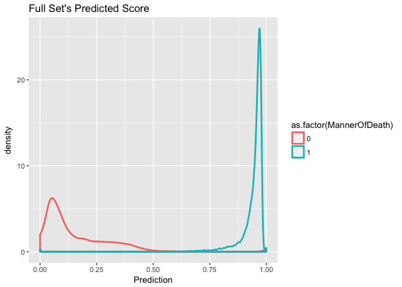

```r
pred_res_f <- fitted(rml, newdata=selected_ms, type='response')

ggplot(selected_ms, aes(pred_res_f, color = as.factor(MannerOfDeath))) +
  geom_density(size = 1) +
  ggtitle("Full Set's Predicted Score") +
  xlab("Prediction")
```

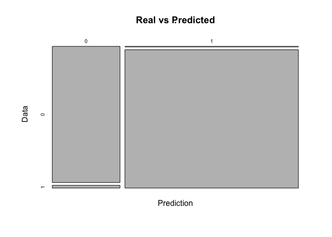

```r
table(selected_ms$MannerOfDeath,ifelse(pred_res_f>0.5,1,0)) %>%
  plot(xlab = "Prediction", ylab = "Data") %>%
  title(main = "Real vs Predicted")
```

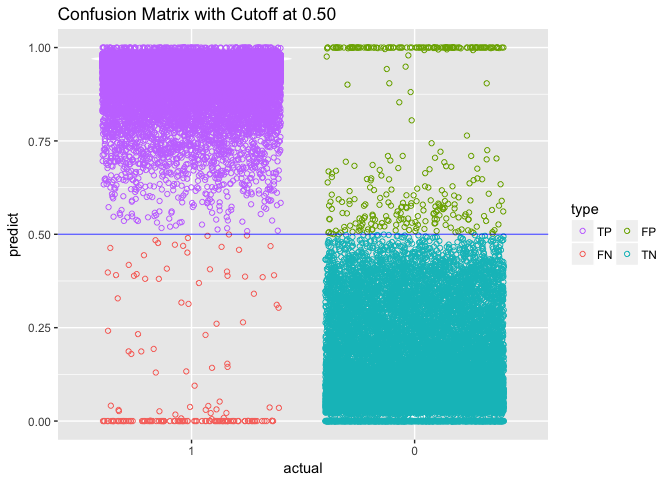

```r
selected_ms['Prediction'] = pred_res_f

cm_info = ConfusionMatrixInfo(data = selected_ms, predict = "Prediction",
                                actual = "MannerOfDeath", cutoff = .5 )
cm_info$plot
```

```r
pred_res_f <- ifelse(pred_res_f>0.5,1,0)

cm = table(pred_res_f, selected_ms$MannerOfDeath)
cm = confusionMatrix(cm)
print(cm)
```

```
Confusion Matrix and Statistics


pred_res_f     0     1
         0 16507   171
         1   333 42968

               Accuracy : 0.9916
                 95% CI : (0.9908, 0.9923)
    No Information Rate : 0.7192
    P-Value [Acc > NIR] : < 2.2e-16

                  Kappa : 0.9791
 Mcnemar's Test P-Value : 7.418e-13

            Sensitivity : 0.9802
            Specificity : 0.9960
         Pos Pred Value : 0.9897
         Neg Pred Value : 0.9923
             Prevalence : 0.2808
         Detection Rate : 0.2752
   Detection Prevalence : 0.2781
      Balanced Accuracy : 0.9881

       'Positive' Class : 0
```

۵. ابتدا ۲۰ درصد داده را به صورت تصادفی به عنوان تست در نظر بگیرید. مدل را با استفاده از ۸۰ درصد باقی مانده برازش دهید. با استفاده از پارامتر قطع ۰.۵ نتایج را برای داده تست پیش بینی کنید. سپس کمیت های زیر را محاسبه کنید.

- P: positive samples
- N: negative samples
- TP: true positive TP (eqv. with hit)
- TN: true negative (eqv. with correct rejection)
- FP: false positive (eqv. with false alarm, Type I error)
- FN: false negative (eqv. with miss, Type II error)
- Accuracy (ACC) ACC = (TP+TN)/(P+T)
- False positive rate (FPR): 1- TN/N
- True positive rate (TPR): TP/P

مشابه آنچه در کلاس گفته شد نمایشی از چهار کمیت TN, TP,FP,FN به همراه داده ها رسم نمایید.

جواب:  
همانند آنچه در سوال ۴ دیده شد، Confusion Matrix به همراه داده ها را مشاهده می کنید که بازهم خطای کمی را گزارش می کند.

```r
set.seed(NULL)
smp_size <- floor(0.8 * nrow(selected_ms))
train_ind <- sample(seq_len(nrow(selected_ms)), size = smp_size)
train <- selected_ms[train_ind, ]
test <- selected_ms[-train_ind, ]
test_t <- test %>% select(-MannerOfDeath)

rml_new = glm(MannerOfDeath~., data = train, family = binomial(link = 'logit'))
pred_res = 0
pred_res <- predict(rml_new, newdata=test_t, type='response')
pred_res <- ifelse(pred_res > 0.5, 1, 0)
test['Prediction'] = pred_res
P = nrow(test %>% filter(MannerOfDeath == 1))
print(P)
```

```
[1] 8670
```

```r
N = nrow(test) - P
print(N)
```

```
[1] 3326
```

```r
TP = nrow(test %>% filter(MannerOfDeath == 1 & Prediction == 1))
print(TP)
```

```
[1] 8626
```

```r
TN = nrow(test %>% filter(MannerOfDeath == 0 & Prediction == 0))
print(TN)
```

```
[1] 3302
```

```r
FP = nrow(test %>% filter(MannerOfDeath == 0 & Prediction == 1))
print(FP)
```

```
[1] 24
```

```r
FN = nrow(test %>% filter(MannerOfDeath == 1 & Prediction == 0))
print(FN)
```

```
[1] 44
```

```r
ACC = (TP+TN)/(P+N)
print(ACC)
```

```
[1] 0.9943314
```

```r
FPR = 1 - TN/N
print(FPR)
```

```
[1] 0.007215875
```

```r
TPR = TP/P
print(TPR)
```

```
[1] 0.994925
```

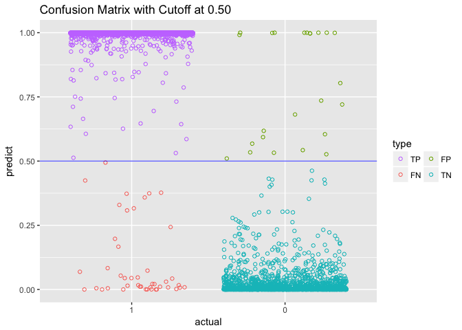

```r
pred_res <- predict(rml_new, newdata=test_t, type='response')
test['Prediction'] = pred_res

cm_info = ConfusionMatrixInfo(data = test, predict = "Prediction",
                                actual = "MannerOfDeath", cutoff = .5 )
cm_info$plot
```

۶. نمودار صحت مدل (accuracy) را بر حسب مقادیر مختلف قطع برای داده تست رسم نمایید. کدام پارامتر قطع بالاترین صحت را در پیش بینی داراست؟

جواب:  
در یک حلقه تمامی این مقادیر بررسی شد و مقدار ماکسیمم در نهایت چاپ می شود و نمودار مطلوب کشیده شده است.

```r
res = vector('integer',1000)
max = -1000
maxi = 0

for(i in 1:1000){
  pred_res_t = predict(rml_new, newdata=test_t, type='response')
  pred_res_t = ifelse(pred_res_t > (i/1000), 1, 0)
  test['Prediction'] = pred_res_t
  P_t = nrow(test %>% filter(MannerOfDeath == 1))
  N_t = nrow(test) - P_t
  TP_t = nrow(test %>% filter(MannerOfDeath == 1 & Prediction == 1))
  TN_t = nrow(test %>% filter(MannerOfDeath == 0 & Prediction == 0))
  ACC_t = (TP_t + TN_t)/(P_t + N_t)
  if(ACC_t > max){
    max = ACC_t
    maxi = i/1000
  }
  res[i] = ACC_t
}
# max acc index (cutoff)
print(maxi)
```

```
[1] 0.605
```

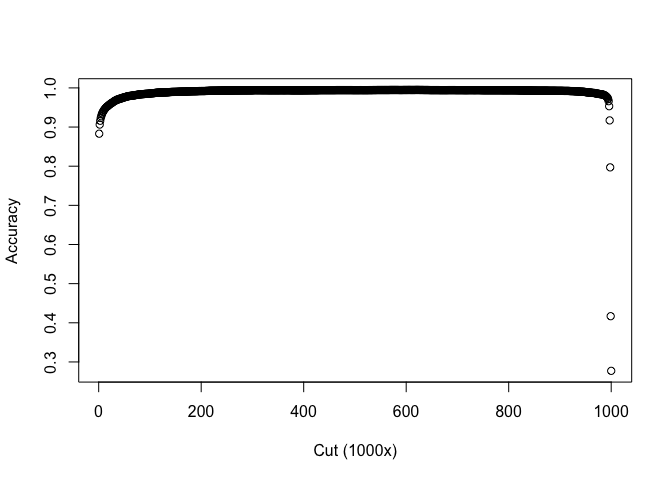

```r
plot(res, xlab = "Cut (1000x)", ylab = "Accuracy")
```

۷. نمودار ROC را برای داده های قسمت قبل رسم نمایید. همچنین نقطه مربوط به بهترین پارامتر قطع را مشخص نمایید.

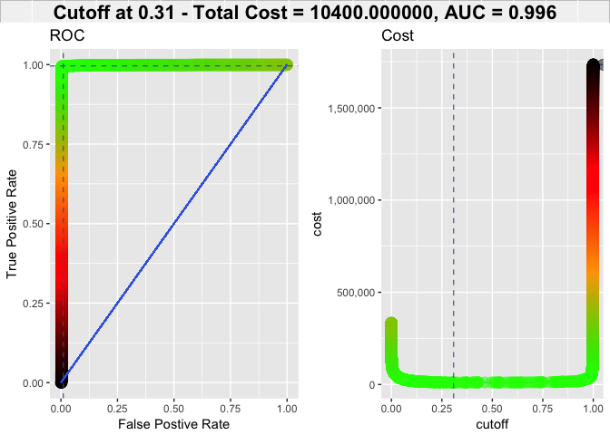

```r
cost_fp = 100;cost_fn = 200
roc_info = ROCInfo(data = cm_info$data, predict = "predict",
                     actual = "actual", cost.fp = cost_fp, cost.fn = cost_fn)
plot(roc_info$plot)
```

۸. با قرار دادن کمیت nfolds = 5 و با استفاده از H20 مدل مساله را بسازید و نتیجه حاصل را ارزیابی کنید.

```r
h2o.init(ip = "localhost", max_mem_size = "2g")
```

[output not shown]

```r
ms_h2o_train <- as.h2o(train)
ms_h2o_test <- as.h2o(test)
Y <- "MannerOfDeath"

X <- c("ActivityCode","AgeRecode12","DayOfWeekOfDeath","Education","HispanicOriginRaceRecode","Disposition","PlaceOfDeathAndDecedentsStatus","PlaceOfInjury","RaceRecode3","ResidentStatus","MonthOfDeath","Sex","CauseRecode39")

dist <- "binomial"

link <- "logit"

id <- "h2o_mdl"

mdl <- h2o.glm(X, Y, training_frame = ms_h2o_train, model_id = id, family = dist, link = link, lambda = 0, compute_p_values = TRUE, standardize = FALSE, nfolds = 5)
show(h2o.getModel(id)@model$coefficients_table)
```

```
Coefficients: glm coefficients
                            names coefficients std_error    z_value
1                       Intercept    42.085379  1.057337  39.803201
2                    ActivityCode    -0.031185  0.002659 -11.726109
3                     AgeRecode12     0.109269  0.007010  15.588176
4                DayOfWeekOfDeath    -0.005874  0.006089  -0.964648
5                       Education     0.060306  0.007935   7.600077
6        HispanicOriginRaceRecode     0.230906  0.007881  29.298666
7                     Disposition     0.039468  0.014821   2.663067
8  PlaceOfDeathAndDecedentsStatus     0.050202  0.006070   8.269916
9                   PlaceOfInjury    -0.022238  0.001333 -16.679502
10                    RaceRecode3    -1.228256  0.018584 -66.091005
11                 ResidentStatus    -0.136927  0.021683  -6.315004
12                   MonthOfDeath    -0.003596  0.003609  -0.996403
13                            Sex     0.157890  0.029048   5.435565
```

[output cut: 16 more lines]

```r
summary(mdl)
```

```
Model Details:
==============

H2OBinomialModel: glm
Model Key:  h2o_mdl
GLM Model: summary
    family  link regularization number_of_predictors_total
1 binomial logit           None                         13
  number_of_active_predictors number_of_iterations training_frame
1                          13                    4          train

H2OBinomialMetrics: glm
** Reported on training data. **

MSE:  0.08893613
RMSE:  0.2982216
LogLoss:  0.3377664
Mean Per-Class Error:  0.109922
AUC:  0.9507931
Gini:  0.9015862
R^2:  0.5604175
Residual Deviance:  32417.1
AIC:  32445.1

Confusion Matrix (vertical: actual; across: predicted) for F1-optimal threshold:
           0     1    Error         Rate
0      12125  1389 0.102782  =1389/13514
1       4035 30434 0.117062  =4035/34469
Totals 16160 31823 0.113040  =5424/47983

Maximum Metrics: Maximum metrics at their respective thresholds
                        metric threshold    value idx
1                       max f1  0.718276 0.918180 156
2                       max f2  0.258568 0.959846 309
3                 max f0point5  0.773059 0.953738 132
4                 max accuracy  0.747886 0.887398 143
5                max precision  0.837188 0.992092  98
6                   max recall  0.001060 1.000000 399
7              max specificity  0.999915 0.993414   0
8             max absolute_mcc  0.761913 0.758098 137
```

[output cut: 67 more lines]

```
specificity        0.8656321  0.9295154

Scoring History:
            timestamp   duration iterations negative_log_likelihood
1 2018-04-27 21:19:47  0.000 sec          0             28525.74458
2 2018-04-27 21:19:47  0.062 sec          1             18127.38579
3 2018-04-27 21:19:47  0.137 sec          2             16216.99338
4 2018-04-27 21:19:47  0.191 sec          3             16208.55803
5 2018-04-27 21:19:47  0.242 sec          4             16208.55018
  objective
1   0.59450
2   0.37779
3   0.33797
4   0.33780
5   0.33780
```

```r
fit_h2o = h2o.predict(mdl, newdata = ms_h2o_test)
summary(fit_h2o)
```

```
 predict          p0                  p1
 Min.   :0.0000   Min.   :4.441e-16   Min.   :0.0003019
 1st Qu.:0.0000   1st Qu.:1.180e-01   1st Qu.:0.6011205
 Median :1.0000   Median :1.580e-01   Median :0.8410480
 Mean   :0.6676   Mean   :3.027e-01   Mean   :0.6973378
 3rd Qu.:1.0000   3rd Qu.:3.979e-01   3rd Qu.:0.8810359
 Max.   :1.0000   Max.   :9.997e-01   Max.   :1.0000000
 StdErr
 Min.   :0.01987
 1st Qu.:0.03387
 Median :0.03912
 Mean   :0.04539
 3rd Qu.:0.04525
 Max.   :0.89507
```

جواب:  
در این سوال بعد از برازش مدل توسط H2O گزارش گیری های لازم را انجام می دهیم و داده های زیادی در اختیار ما قرار می گیرد مثل ضرایب، بیشترین میزان ترشولد برای هردو گروه، میزان دقت و صحت و حساسیت مدل و کمینه و بیشنه ی خطا که مقادیری مناسبی هستند و مدل با دقت بالایی را توصیف می کنند. همین مقادیر برای کافولد با عدد ۵ نیز دوباره تکرار شده که صحت نتایج را تصدیق می کند. برای پیش بینی نیز متوسط میزان خطا برای هردو گروه دیده می شود و خطای استاندارد نیز مشاهده می شود که مقادیر همگی دقت بالایی را به مدل نسبت می دهند.

۹. آیا ما میتوانیم سرویسی به قضات ارایه کنیم تا با استفاده از اطلاعات مرگ بتوانند موارد مشکوک به قتل را از خودکشی تفکیک دهند؟

جواب: شاید با درست خطای بسیارکمی بشه روی این اطلاعات نظرداد ولی در دنیای واقعی یک خطاهم موجود از بین رفتن یک انسان می شود و ممکن است مورد پیش آمده یک مورد خاص بوده باشد و به همین دلیل به نظر من نمی توان به آن در راستای قضاوت استناد کرد.